# PML Project - Qualified Health Tracker Measurement

#### Project Overview

With fitness trackers devices like Fitbits, Nike Fuel Band, Jawbone up, the amount of fitness data that one can capture about their own activity has multiplied. Such data capture has become very easy to do and is fairly inexpensive. For the most part, the primary focus of users adopting these devices was to auanitify how much of an activity they are doing (*numbers of steps*, *number of miles walked*, *number of calories burned*, etc.). In this project, we will shift the focus to seeing how well a set of users are actually doing the activities they are tracking.

*Process:* to achieve our goal, we will use data from accelerometers on the belt, forearm, arm, and dumbell of `6 participants` to predict the manner in which they completed their exercises.

The participants were asked to perform one set of 10 repetitions of the Unilateral Dumbbell Biceps Curl in five different ways:

- *Class A*: exactly according to the specification.
- *Class B*: throwing the elbows to the front.
- *Class C*: lifting the dumbbell only halfway.
- *Class D*: lowering the dumbbell only halfway.
- *Class E*: throwing the hips to the front.

(See the Annex for the data source & a full citation with further details around the measurement).

##### Loading of necessary packages

```r
library(caret)
library(randomForest)
library(ggplot2)
```

##### Getting the Data

```r
# Capture the CSV files needed to training and testing
urlTrain <- "https://d396qusza40orc.cloudfront.net/predmachlearn/pml-training.csv"
urlTest <- "https://d396qusza40orc.cloudfront.net/predmachlearn/pml-testing.csv"
# Download the file in the working directory (read.csv is sufficient and allows to define NA strings).
trainFull <- read.csv(urlTrain, na.strings=c('NA','','#DIV/0!'))
testFull <- read.csv(urlTest, na.strings=c('NA','','#DIV/0!'))
# Verify the structure of the Train and Test files.
dim(trainFull)
```

```
## [1] 19622   160
```

```r
dim(testFull)
```

```
## [1]  20 160
```

##### Data Clean-up and Preprocessing

In this section, the training data `trainFile` is not in a shape that can be used to perform any modeling. Several portion of the data include `NAs`or are missing values entirely (see Annex). Since the project requires us to develp a model to predict the outcome variable `classe`, multiple predictors should also be looked at to determine if they are worth using. *Note:* Any transformation applied to the original `trainFile` will also be applied to the final test data set `testQuiz`.

```r
# Remove NAs, #DIV/0!', empty spaces & the 1st column that's just an index
trainFile <- trainFull[, colSums(is.na(trainFull)) == 0]
trainFile <- trainFile[, -1]
dim(trainFile)
```

```
## [1] 19622    59
```

```r
testQuiz <- testFull[, colSums(is.na(testFull)) == 0]
testQuiz <- testQuiz[, -1]
dim(testQuiz)
```

```
## [1] 20 59
```

##### Developing the analysis Model

Considering the `trainFile` data frame includes 19622 observations, splitting it into a training and validation set makes sense to test the validation of the model to develop.

```r
set.seed(12345)
partition <- createDataPartition(trainFile$classe, p=3/4, list=FALSE)
trainingSet <- trainFile[partition,]
validationSet <- trainFile[-partition,]
dim(trainingSet)
```

```
## [1] 14718    59
```

```r
dim(validationSet)
```

```
## [1] 4904   59
```

```r
set.seed(333)
```

###### Building our model

Under the premise of the project to detemine the quality of the exercises, a prediciton model to determine which `classe` performned best could be a classification exercise. One of the best algorithms for such a process is using a `random forest` model even though is can be process intensive.

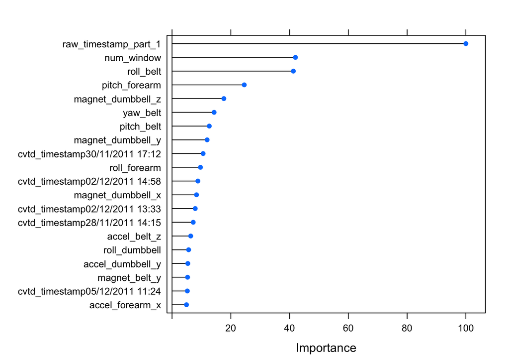

```r
#BeginTS <- Sys.time();
#
modelTrain <- train(classe ~., method="rf", data=trainingSet, trControl=trainControl(method="cv"),number = 5, allowParallel=TRUE)
#
#EndTS <- Sys.time();
#duration <- EndTS - BeginTS
#cat("The execution time of random forest model took about: ", duration, "min.")

# plot most imfluential predictors
plot(varImp(modelTrain), top=20)
```

From the built model, we look at a the variable importance plot to see if some predictors are more influential than others. We can see some variables related to time stamps appear with high importance, said variables however only serve to capture the time stamp of exercises and don’t determine quality, we will subset them from the training, validation and testing datasets to focus on predictors related to the quality of the ‘Biceps Curl’ exercise and refit the model.

```r
# Remove the time stamp columns from train, validation and test files
removeTS <- grepl("*_time*", names(trainingSet))
trainingSet = trainingSet[, !removeTS]
validationSet = validationSet[, !removeTS]
testQuiz = testQuiz[, !removeTS]
modelTrain <- train(classe ~., method="rf", data=trainingSet, trControl=trainControl(method="cv"),number = 5, allowParallel=TRUE)
```

###### Model Accuracy

To capture the accuracy of the prediction, we first compute the prediction model on the validation set and extract its confusion matrix.

```r
# Build the Random Forest prediction
predTrain <- predict(modelTrain, validationSet)
CFtrain <- confusionMatrix(predTrain, validationSet$classe)
CFtrain
```

```
## Confusion Matrix and Statistics
##
##           Reference
## Prediction    A    B    C    D    E
##          A 1395    3    0    0    0
##          B    0  941    2    0    0
##          C    0    5  853    3    0
##          D    0    0    0  801    4
##          E    0    0    0    0  897
##
## Overall Statistics
##
##                Accuracy : 0.9965
##                  95% CI : (0.9945, 0.998)
##     No Information Rate : 0.2845
##     P-Value [Acc > NIR] : < 2.2e-16
##
##                   Kappa : 0.9956
##  Mcnemar's Test P-Value : NA
##
## Statistics by Class:
##
##                      Class: A Class: B Class: C Class: D Class: E
## Sensitivity            1.0000   0.9916   0.9977   0.9963   0.9956
## Specificity            0.9991   0.9995   0.9980   0.9990   1.0000
## Pos Pred Value         0.9979   0.9979   0.9907   0.9950   1.0000
## Neg Pred Value         1.0000   0.9980   0.9995   0.9993   0.9990
## Prevalence             0.2845   0.1935   0.1743   0.1639   0.1837
## Detection Rate         0.2845   0.1919   0.1739   0.1633   0.1829
## Detection Prevalence   0.2851   0.1923   0.1756   0.1642   0.1829
## Balanced Accuracy      0.9996   0.9955   0.9978   0.9976   0.9978
```

From applying a `random forest` algorithm we can extract the accuracy metric fom the confusionMatrix as well as calculate the out of sample error as follows:

```r
CFtrain$overall[1]
```

```
##  Accuracy
## 0.9965334
```

```r
OOSE <- 1 - as.numeric(CFtrain$overall[1])
OOSE
```

```
## [1] 0.003466558
```

We can see that applying the prediction model on the validation data set a 99.65% accuracy with a tiny out of sample error 0.35%, which allows us to be pretty confident in this model.

##### Final Validation on Test Data

Finally, we can validate our developed model on the testing data for the `20 test cases` in the quiz part of this project.

```r
predTest <- predict(modelTrain, testQuiz)
predTest
```

```
##  [1] B A B A A E D B A A B C B A E E A B B B
## Levels: A B C D E
```

\newpage

## Annex

##### Data Source

- The data used has been provided under CC license (CC BY-SA) by: http://groupware.les.inf.puc-rio.br/har
- *Velloso, E.; Bulling, A.; Gellersen, H.; Ugulino, W.; Fuks, H.* [Qualitative Activity Recognition of Weight Lifting Exercises](http://groupware.les.inf.puc-rio.br/har#weight_lifting_exercises#ixzz4B6khjQsq). *Proceedings of 4th International Conference in Cooperation with SIGCHI (Augmented Human ’13) . Stuttgart, Germany: ACM SIGCHI, 2013.*

##### Training Data Sctructure

```r
# Training data structure
str(trainFull)
```

```
## 'data.frame':    19622 obs. of  160 variables:
##  $ X                       : int  1 2 3 4 5 6 7 8 9 10 ...
##  $ user_name               : Factor w/ 6 levels "adelmo","carlitos",..: 2 2 2 2 2 2 2 2 2 2 ...
##  $ raw_timestamp_part_1    : int  1323084231 1323084231 1323084231 1323084232 1323084232 1323084232 1323084232 1323084232 1323084232 1323084232 ...
##  $ raw_timestamp_part_2    : int  788290 808298 820366 120339 196328 304277 368296 440390 484323 484434 ...
##  $ cvtd_timestamp          : Factor w/ 20 levels "02/12/2011 13:32",..: 9 9 9 9 9 9 9 9 9 9 ...
##  $ new_window              : Factor w/ 2 levels "no","yes": 1 1 1 1 1 1 1 1 1 1 ...
##  $ num_window              : int  11 11 11 12 12 12 12 12 12 12 ...
##  $ roll_belt               : num  1.41 1.41 1.42 1.48 1.48 1.45 1.42 1.42 1.43 1.45 ...
##  $ pitch_belt              : num  8.07 8.07 8.07 8.05 8.07 8.06 8.09 8.13 8.16 8.17 ...
##  $ yaw_belt                : num  -94.4 -94.4 -94.4 -94.4 -94.4 -94.4 -94.4 -94.4 -94.4 -94.4 ...
##  $ total_accel_belt        : int  3 3 3 3 3 3 3 3 3 3 ...
##  $ kurtosis_roll_belt      : num  NA NA NA NA NA NA NA NA NA NA ...
##  $ kurtosis_picth_belt     : num  NA NA NA NA NA NA NA NA NA NA ...
##  $ kurtosis_yaw_belt       : logi  NA NA NA NA NA NA ...
```

[output cut: 86 more lines]

```r
head(trainFile$classe)
```

```
## [1] A A A A A A
## Levels: A B C D E
```

```r
class(trainFile$classe)
```

```
## [1] "factor"
```